# W271 - Assignment2

Chandra Shekar Bikkanur

10/6/2019

```r
#Loading some libraries for this assignment
library(car)
library(dplyr)
library(Hmisc)
library(ggplot2)
library(mcprofile)
library(nnet)
library(MASS)
library(GGally)
```

# 1. Strategic Placement of Products in Grocery Stores

Let us load the data into a data frame and do the initial EDA of the data

```r
cereal <- read.csv("cereal_dillons.csv", header=TRUE, sep=",")
head(cereal, 5)
```

|  | ID | Shelf | Cereal | size_g | sugar_g | fat_g | sodium_mg |
| --- | --- | --- | --- | --- | --- | --- | --- |
| 1 | 1 | 1 | Kellog's Razzle Dazzle Rice Crispies | 28 | 10 | 0 | 170 |
| 2 | 2 | 1 | Post Toasties Corn Flakes | 28 | 2 | 0 | 270 |
| 3 | 3 | 1 | Kellogg's Corn Flakes | 28 | 2 | 0 | 300 |
| 4 | 4 | 1 | Food Club Toasted Oats | 32 | 2 | 2 | 280 |
| 5 | 5 | 1 | Frosted Cheerios | 30 | 13 | 1 | 210 |

```r
str(cereal)
```

```
## 'data.frame':    40 obs. of  7 variables:
##  $ ID       : int  1 2 3 4 5 6 7 8 9 10 ...
##  $ Shelf    : int  1 1 1 1 1 1 1 1 1 1 ...
##  $ Cereal   : Factor w/ 38 levels "Basic 4","Capn Crunch",..: 17 34 19 13 16 9 2 3 30 8 ...
##  $ size_g   : int  28 28 28 32 30 31 27 27 29 33 ...
##  $ sugar_g  : int  10 2 2 2 13 11 12 9 11 2 ...
##  $ fat_g    : num  0 0 0 2 1 0 1.5 2.5 0.5 0 ...
##  $ sodium_mg: int  170 270 300 280 210 180 200 200 220 330 ...
```

We see that *Shelf* is of integer type. This should be changed to a *factor* data type to do any regressions on the data.

**1.1 (1 point):** The explanatory variables need to be reformatted before proceeding further (sample code is provided in the textbook). First, divide each explanatory variable by its serving size to account for the different serving sizes among the cereals. Second, rescale each variable to be within 0 and 1. Construct side-by-side box plots with dot plots overlaid for each of the explanatory variables. Also, construct a parallel coordinates plot for the explanatory variables and the shelf number. Discuss whether possible content differences exist among the shelves.

```r
stand01 <- function(x) { (x - min(x))/(max(x) - min(x)) } # function to standardize a dataset
cereal2 <- data.frame(Shelf = cereal$Shelf, sugar = stand01(x = cereal$sugar_g/cereal$size_g), fat = stand01(x = cereal$fat_g/cereal$size_g), sodium = stand01(x = cereal$sodium_mg/cereal$size_g)) # new data frame consisting of Shelf, sugar, fat and sodium
str(cereal2)
```

```
## 'data.frame':    40 obs. of  4 variables:
##  $ Shelf : int  1 1 1 1 1 1 1 1 1 1 ...
##  $ sugar : num  0.643 0.129 0.129 0.112 0.78 ...
##  $ fat   : num  0 0 0 0.675 0.36 ...
##  $ sodium: num  0.567 0.9 1 0.817 0.653 ...
```

```r
tail(cereal2, 5)
```

|  | Shelf | sugar | fat | sodium |
| --- | --- | --- | --- | --- |
| 36 | 4 | 0.3483871 | 0.3483871 | 0.1956989 |
| 37 | 4 | 0.4581818 | 0.5890909 | 0.1696970 |
| 38 | 4 | 0.6218182 | 0.3927273 | 0.4412121 |
| 39 | 4 | 0.5563636 | 0.5890909 | 0.4751515 |
| 40 | 4 | 0.1800000 | 0.0000000 | 0.6222222 |

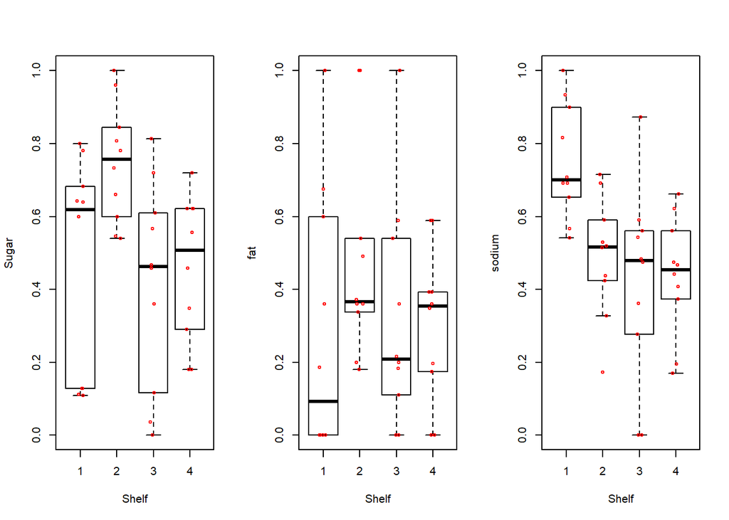

```r
par(mfrow=c(1,3))
boxplot(formula = sugar ~ Shelf, data = cereal2, ylab = "Sugar", xlab = "Shelf", pars = list(outpch=NA))
stripchart(x = cereal2$sugar ~cereal2$Shelf, lwd = 1, col = "red", method = "jitter", vertical = TRUE, pch = 1, add = TRUE)
boxplot(formula = fat ~ Shelf, data = cereal2, ylab = "fat", xlab = "Shelf", pars = list(outpch=NA))
stripchart(x = cereal2$fat ~cereal2$Shelf, lwd = 1, col = "red", method = "jitter", vertical = TRUE, pch = 1, add = TRUE)
boxplot(formula = sodium ~ Shelf, data = cereal2, ylab = "sodium", xlab = "Shelf", pars = list(outpch=NA))
stripchart(x = cereal2$sodium ~cereal2$Shelf, lwd = 1, col = "red", method = "jitter", vertical = TRUE, pch = 1, add = TRUE)
```

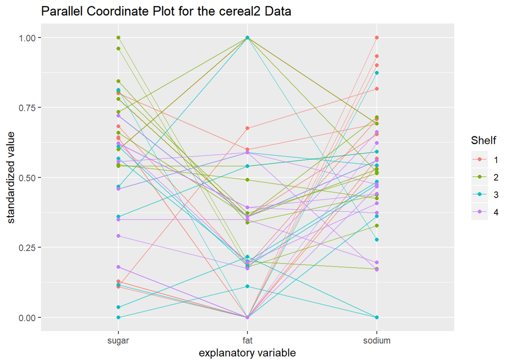

```r
ggparcoord(cereal2, columns = 2:4, groupColumn = 'Shelf', scale = 'globalminmax', showPoints = TRUE, title = "Parallel Coordinate Plot for the cereal2 Data", alphaLines = 0.6, mapping=aes(color=as.factor(Shelf)))+ xlab("explanatory variable") + ylab("standardized value") +scale_color_discrete("Shelf")
```

**1.2 (1 point):** The response has values of $1, 2, 3,$ and $4$. Explain under what setting would it be desirable to take into account ordinality, and whether you think that this setting occurs here. Then estimate a suitable multinomial regression model with linear forms of the sugar, fat, and sodium variables. Perform LRTs to examine the importance of each explanatory variable. Show that there are no significant interactions among the explanatory variables (including an interaction among all three variables).

If placing cereals in shelf 4 (top shelf) is more conducive in the likelihood of purchasing cereals from shelf 4 than shelf 1 (bottom), then we can take ordinality into account. Here, we do not have such information about the shelves. So, we can try to fit a nominal response regression model for the *Shelf* with *fat*, *sugar* and *sodium* as explanatory variables.

```r
cereal2$Shelf <- as.factor(cereal2$Shelf) # convert int data_type of Shelf to factor
mod.fit.nom <- multinom(Shelf~sugar + fat + sodium, data = cereal2)
summary(mod.fit.nom)
```

```
## Call:
## multinom(formula = Shelf ~ sugar + fat + sodium, data = cereal2)
##
## Coefficients:
##   (Intercept)      sugar        fat    sodium
## 2    6.900708   2.693071  4.0647092 -17.49373
## 3   21.680680 -12.216442 -0.5571273 -24.97850
## 4   21.288343 -11.393710 -0.8701180 -24.67385
##
## Std. Errors:
##   (Intercept)    sugar      fat   sodium
## 2    6.487408 5.051689 2.307250 7.097098
## 3    7.450885 4.887954 2.414963 8.080261
## 4    7.435125 4.871338 2.405710 8.062295
##
## Residual Deviance: 67.19028
## AIC: 91.19028
```

```r
Anova(mod.fit.nom) # performing LR Test
```

|  | LR Chisq | Df | Pr(>Chisq) |
| --- | --- | --- | --- |
| sugar | 22.76484 | 3 | 4.520699e-05 |
| fat | 5.28356 | 3 | 1.521727e-01 |
| sodium | 26.61974 | 3 | 7.073281e-06 |

From above LR test for the *mod.fit.nom* model, we can see that *suagr* and *sodium* have significance in determining the *Shelf* the cereals could be placed in. Let us now check if these explanatory varaibles have any interactions among them

```r
mod.fit.nom2 <- multinom(Shelf~sugar + fat + sodium + sugar*fat + sugar*sodium + fat*sodium + sugar*fat*sodium, data = cereal2)
summary(mod.fit.nom2)
```

```
## Call:
## multinom(formula = Shelf ~ sugar + fat + sodium + sugar * fat +
##     sugar * sodium + fat * sodium + sugar * fat * sodium, data = cereal2)
##
## Coefficients:
##   (Intercept)      sugar       fat     sodium sugar:fat sugar:sodium
## 2   -4.563627   8.944868 22.063003   1.030077  35.60873   -12.250084
## 3   24.498320 -22.248456 35.981865 -27.899087 -17.12487    13.253103
## 4   27.246742 -21.852777  7.298799 -29.106797  41.08251     2.887805
##   fat:sodium sugar:fat:sodium
## 2  -23.75955        -55.88455
## 3  -59.54150         37.71571
## 4  -30.85250        -22.59552
##
## Std. Errors:
##   (Intercept)    sugar       fat   sodium sugar:fat sugar:sodium
## 2    25.21113 29.72894  96.57821 27.29915  135.1117     31.98647
## 3    22.83750 25.81043 101.17670 24.61166  150.1228     26.89827
## 4    22.80359 26.00692 100.83444 24.51538  150.6750     28.86631
##   fat:sodium sugar:fat:sodium
## 2   116.0776         158.8091
## 3   138.0237         212.2222
## 4   138.5448         217.3953
##
## Residual Deviance: 53.54496
## AIC: 101.545
```

```r
Anova(mod.fit.nom2) # performing LR Test
```

|  | LR Chisq | Df | Pr(>Chisq) |
| --- | --- | --- | --- |
| sugar | 19.252472 | 3 | 2.424257e-04 |
| fat | 6.116697 | 3 | 1.060686e-01 |
| sodium | 30.840705 | 3 | 9.182935e-07 |
| sugar:fat | 3.230922 | 3 | 3.573733e-01 |
| sugar:sodium | 3.018482 | 3 | 3.887844e-01 |
| fat:sodium | 3.158583 | 3 | 3.678151e-01 |
| sugar:fat:sodium | 2.588382 | 3 | 4.595299e-01 |

From above LR test for *mod.fit.nom2* model, we can see that there are no explanatory variables’ interactions in determining the *Shelf*.

```r
#cereal2$Shelf <- as.factor(cereal2$Shelf) # convert int data_type of Shelf to factor
#cereal2$Shelf.order <- factor(cereal2$Shelf, levels = c("1", "2", "3", "4")) # declare the ordinality levels
#levels(cereal2$Shelf.order)
#mod.fit.ord <- polr(Shelf.order~sugar + fat + sodium, data = cereal2, method = "logistic")
#summary(mod.fit.ord)
#Anova(mod.fit.ord)
```

**1.3 (1 point):** Kellogg’s Apple Jacks (http://www.applejacks.com) is a cereal marketed toward children. For a serving size of $28$ grams, its sugar content is $12$ grams, fat content is $0.5$ grams, and sodium content is $130$ milligrams. Estimate the shelf probabilities for Apple Jacks.

```r
stand01_2 <- function(x, min , max) { (x - min)/(max - min) } # function to standardize a dataset
Kellogs_data <- data.frame(sugar = stand01_2(x = 12/28, min = min(cereal$sugar_g/cereal$size_g), max  = max(cereal$sugar_g/cereal$size_g)), fat = stand01_2(x = 0.5/28, min = min(cereal$fat_g/cereal$size_g), max =  max(cereal$fat_g/cereal$size_g)), sodium = stand01_2(x = 130/28, min = min(cereal$sodium_mg/cereal$size_g), max =  max(cereal$sodium_mg/cereal$size_g)))
str(Kellogs_data)
```

```
## 'data.frame':    1 obs. of  3 variables:
##  $ sugar : num 0.771
##  $ fat   : num 0.193
##  $ sodium: num 0.433
```

```r
pi.hat <- predict(object = mod.fit.nom, newdata = Kellogs_data, type = "probs")
pi.hat
```

```
##          1          2          3          4
## 0.05326849 0.47194264 0.20042742 0.27436145
```

**1.4 (1 point):** Construct a plot similar to Figure 3.3 where the estimated probability for a shelf is on the *y-axis* and the sugar content is on the *x-axis*. Use the mean overall fat and sodium content as the corresponding variable values in the model. Interpret the plot with respect to sugar content.

```r
sugar <- seq(0,1, 0.01)
mean_fat <- mean(cereal2$fat)
mean_sodium <- mean(cereal2$sodium)
new_data = data.frame(sugar=sugar, fat=mean_fat,sodium=mean_sodium)
head(new_data)
```

|  | sugar | fat | sodium |
| --- | --- | --- | --- |
| 1 | 0.00 | 0.3475739 | 0.524039 |
| 2 | 0.01 | 0.3475739 | 0.524039 |
| 3 | 0.02 | 0.3475739 | 0.524039 |
| 4 | 0.03 | 0.3475739 | 0.524039 |
| 5 | 0.04 | 0.3475739 | 0.524039 |
| 6 | 0.05 | 0.3475739 | 0.524039 |

```r
pi.hat <- predict(object = mod.fit.nom, newdata = new_data, type = "probs")
pi.hat_df <- as.data.frame(pi.hat, columns= c("Shelf1", "Shelf2", "Shelf3", "Shelf4"))
pi.hat_df$sugar <- sugar
head(pi.hat_df)
```

|  | 1 | 2 | 3 | 4 | sugar |
| --- | --- | --- | --- | --- | --- |
| 1 | 0.0001317725 | 5.610226e-05 | 0.5844393 | 0.4153729 | 0.00 |
| 2 | 0.0001483820 | 6.489817e-05 | 0.5824254 | 0.4173613 | 0.01 |
| 3 | 0.0001670817 | 7.507165e-05 | 0.5804070 | 0.4193508 | 0.02 |
| 4 | 0.0001881341 | 8.683815e-05 | 0.5783837 | 0.4213413 | 0.03 |
| 5 | 0.0002118348 | 1.004468e-04 | 0.5763554 | 0.4233323 | 0.04 |
| 6 | 0.0002385160 | 1.161856e-04 | 0.5743218 | 0.4253235 | 0.05 |

```r
pi.hat_df <- as.data.frame(pi.hat)
pi.hat_df$sugar <- sugar
names(pi.hat_df) <- c("Shelf_1", "Shelf_2", "Shelf_3", "Shelf_4", "Sugar")
head(pi.hat_df)
```

|  | Shelf_1 | Shelf_2 | Shelf_3 | Shelf_4 | Sugar |
| --- | --- | --- | --- | --- | --- |
| 1 | 0.0001317725 | 5.610226e-05 | 0.5844393 | 0.4153729 | 0.00 |
| 2 | 0.0001483820 | 6.489817e-05 | 0.5824254 | 0.4173613 | 0.01 |
| 3 | 0.0001670817 | 7.507165e-05 | 0.5804070 | 0.4193508 | 0.02 |
| 4 | 0.0001881341 | 8.683815e-05 | 0.5783837 | 0.4213413 | 0.03 |
| 5 | 0.0002118348 | 1.004468e-04 | 0.5763554 | 0.4233323 | 0.04 |
| 6 | 0.0002385160 | 1.161856e-04 | 0.5743218 | 0.4253235 | 0.05 |

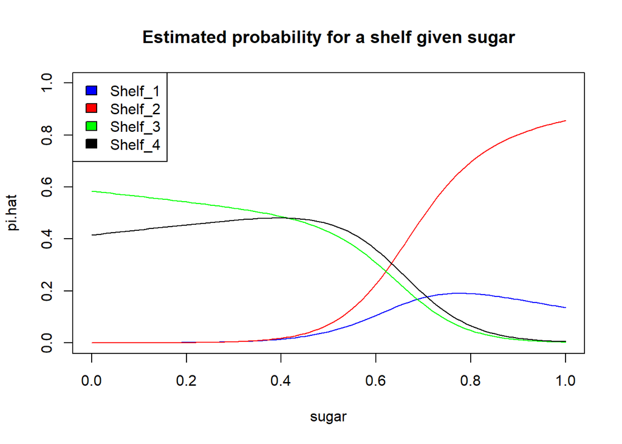

```r
plot(pi.hat_df$Sugar,pi.hat_df$Shelf_1,type="l",col="blue", main="Estimated probability for a shelf given sugar",ylab="pi.hat", xlab = "sugar", ylim = c(0,1))
lines(pi.hat_df$Sugar,pi.hat_df$Shelf_2, col="red")
lines(pi.hat_df$Sugar,pi.hat_df$Shelf_3, col="green")
lines(pi.hat_df$Sugar,pi.hat_df$Shelf_4, col="black")
legend("topleft",
c("Shelf_1","Shelf_2","Shelf_3","Shelf_4"),
fill=c("blue","red","green","black")
)
```

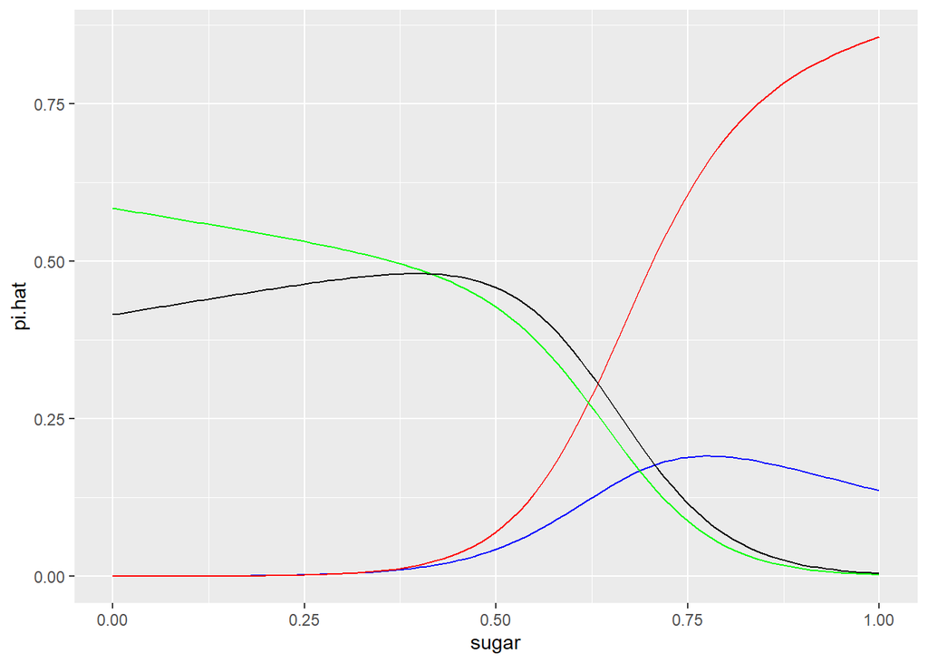

```r
g <- ggplot(pi.hat_df, aes(Sugar))
g <- g + geom_line(aes(y=Shelf_1), colour="blue")
g <- g + geom_line(aes(y=Shelf_2), colour="red")
g <- g + geom_line(aes(y=Shelf_3), colour="green")
g <- g + geom_line(aes(y=Shelf_4), colour="black")
g <- g + ylab("pi.hat") + xlab("sugar")
g
```

**1.5 (1 point):** Estimate odds ratios and calculate corresponding confidence intervals for each explanatory variable. Relate your interpretations back to the plots constructed for this exercise.